# Publishing Jupter SlideShows on GitHub/GitLab

**Pre-requisites:**

- Have Jupyter notebook installed
- Have a GitHub/GitLab account

**Table of Contents:**

- Part 0: Intro/Example (what publishing your slideshow can look like)
- Part 1: Set up your SlideShow with Jupyter Notebook
- Part 2: Create the html slideshow file
- Part 3: Publish your slideshow to Github or GitLab
- Part 4: Resources & more details

### Part 0: Intro/Example (what publishing your slideshow can look like)

Example: Distribution of restaurant spend by day of week

[figure not shown]

⬇️ click down arrow for more details ➡️ click right arrow to go to part 1

The data is some sample dataset from the seaborn module.  
The dataset is called "tips" and is loaded with "load_dataset".

⬇️ click down arrow for more details ➡️ **double**-click right arrow to go to part 1

```python
import seaborn as sns
sns.set_theme(style="whitegrid")
tips = sns.load_dataset("tips")
tips.head()
```

|  | total_bill | tip | sex | smoker | day | time | size |
| --- | --- | --- | --- | --- | --- | --- | --- |
| 0 | 16.99 | 1.01 | Female | No | Sun | Dinner | 2 |
| 1 | 10.34 | 1.66 | Male | No | Sun | Dinner | 3 |
| 2 | 21.01 | 3.50 | Male | No | Sun | Dinner | 3 |
| 3 | 23.68 | 3.31 | Male | No | Sun | Dinner | 2 |
| 4 | 24.59 | 3.61 | Female | No | Sun | Dinner | 4 |

The chart is generated with seaborn (boxplot)  
x-axis is the day of the week  
y-axis is the spend at the restaurant (i.e. the total bill)

⬇️ click down arrow for more details ➡️ **double**-click right arrow to go to part 1

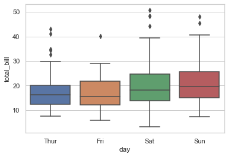

```python
ax = sns.boxplot(x="day", y="total_bill", data=tips)
```

### Part 1: Creating a SlideShow with Jupyter Notebook

First go to View>Cell Toolbar>SlideShow

[figure not shown]

⬇️ click down arrow for more details or ➡️ click right arrow to go to part 2

Then select the type for each slide

[figure not shown]

⬇️ click down arrow for more details ➡️ click right arrow to go to part 2

Then select the Slide Type:

- Slide — move through slides from left to right
- Sub-Slide — add a slide below the previous one
- Fragment — add a fragment to the previous slide
- Skip — do not create a slide from a cell
- Notes — also no slide is created here

➡️ click right arrow to go to part 2

### Part 2: Creating a SlideShow with Jupyter Notebook

To create a slideshow, you need to execute one of the following commands in the Command Line (Windows) or Terminal(MacOS):

> jupyter nbconvert [notebook_name].ipynb --to slides --stdout > index.html

*or alternatively to hide code cell*:

> jupyter nbconvert [notebook_name].ipynb --no-input --no-prompt --to slides --stdout > index.html

*or alternatively - not my preferred option as it tends to zoom in on the page*:

> jupyter nbconvert Jupyter\ [notebook_name].ipynb --to slides --post serve

⬇️ click down arrow for more details ➡️ click right arrow to go to part 3

In my case:

> jupyter nbconvert Jupyter\ jupyter_slideshow_Gitlab.ipynb --to slides --stdout > index.html

This will create an HTLM file that contains your slideshow  
Your HTML file will be in the same folder as that of all your ipynb notebooks by default

### Part 3: Host on/Deploy to GitHub or GitLab

#### If you manually publish on GithHub

- Upload the html file in your repo, and make sure it is renamed as index.html
- Upload the jupyter notebook (ipynb file)
- See at https://[yourusername].github.io/[your_repo_name]/

#### If you manually publish on GitLab

⚠️ When using a corporate GitLab, connect via VPN; or else GitLab might not serve the pages

- New project >Create from template>Pages/plain html
- Go into public folder then swap the index.html with your own html file (rename it as "index.html")
- On the left side, go to Settings>pages

You can see your pages are either served under:

- https://[yourusername].gitlab.io/[your_repo_name] (Personal account) or
- https://[yourusername].pages.[companyname].com/[your_repo_name] (Company account)

⬇️ click down arrow for more details ➡️ click right arrow to go to part 4

#### If you use Git commands to push your local repo to Github

The below commands should be executed via your Command Line (Windows) or Terminal(MacOS)  
You need to be at the root of your project folder before executing the commands (use "change directory" [cd] to navigate)

> git init : creates a local git repository  
> git add . : adds all changes to the staging area  
> git commit -m "Commit xxx" : commits all changes in staging

> git remote add origin git@github.com:[username]/[yourRepo].git  
> : connects to your remote repository and names it "origin"  
> git push -u origin main : pushes local repo to your remote repo

see at https://[username].github.io/[yourRepo]/

### Part 4: Resources & more details

Link 1: https://medium.com/@mjspeck/presenting-code-using-jupyter-notebook-slides-a8a3c3b59d67

Link 2: https://sophiamyang.github.io/DS/basics/slides_github_pages.html